# Estudio de Caso Cancún: Análisis Hidráulico, Ambiental y Financiero con gravitypool

Ricardo Ochoa Sosa

## 1. Introducción y Contexto del Proyecto

El diseño y operación de albercas semi-olímpicas y recreativas en climas tropicales (como Cancún, Quintana Roo) enfrenta tres desafíos simultáneos:

1. **Altas Tasas de Recambio Normativo:** La temperatura del agua (28 °C a 30 °C) acelera la proliferación microbiana, exigiendo típicamente **4 recambios de volumen diarios** (turnovers) para cumplir con directrices sanitarias internacionales (DIN 19643).
2. **Topografía Plana y Costo Estructural:** La península de Yucatán carece de desniveles orográficos naturales (desnivel = 0.0 m), requiriendo que cualquier altura hidrostática sea erigida mediante obra civil.
3. **Penalización Tarifaria Extrema:** La operación ininterrumpida (24/7) de grupos de bombeo sobrepasa los umbrales de baja tensión, obligando a contratar la tarifa comercial **CFE GDMTH (Gran Demanda en Media Tensión Horaria)**, la cual castiga severamente el consumo en horario punta (18:00 a 22:00 hrs) y cobra cargos mensuales fijos por demanda máxima coincidente.

El paquete `gravitypool` permite evaluar rigurosamente la sustitución o hibridación de estos sistemas frente a dos alternativas: - Almacenamiento electroquímico con bancos de baterías de litio-ferrofosfato (LiFePO4 / LFP). - Almacenamiento potencial gravitacional con bypass nocturno de baja presión.

```r
library(gravitypool)
library(ggplot2)
library(dplyr)
```

## 2. Ingesta de Datos e Instanciación del Escenario (Clase S3)

Cargamos el caso de estudio de Cancún preconfigurado a partir de los datos situacionales:

```r
# Carga directa del archivo de investigación JSON integrado
escenario_cancun <- load_pool_scenario()
print(escenario_cancun)
```

```
#> =========================================================
#>   gravitypool :: ESCENARIO DE INSTALACIÓN ACUÁTICA
#> =========================================================
#>   Proyecto:          Alberca de Entrenamiento 25m - Cancún (Cancún, Quintana Roo)
#>   Dimensiones:       25.0 m x 12.5 m x 1.35 m
#>   Volumen Total:     421.88 m3 (421875 litros)
#>   Recambios Diarios: 4.0 turnovers/dia (1687.50 m3/dia)
#>   Red Hidráulica:    PVC_Sch40 3.0" (L = 45.0 m) | Filtro: sand_high_rate
#> ---------------------------------------------------------
#>   Bombeo Actual:     3 bombas x 3.0 HP (Total: 6.71 kW)
#>   Consumo Eléctrico: 161.0 kWh/dia (TDH est.: 18.0 m.c.a.)
#>   Tarifa:            CFE_GDMTH_Peninsular ($3.15 MXN/kWh)
#>   Solar & Clima:     5.2 HSP | Temp: 28.0 °C | TC: $18.50 MXN/USD
#> =========================================================
```

## 3. Simulación de Gravedad Pura (Demostración de Inviabilidad Estructural)

La primera hipótesis analizada por un consultor novato suele ser: *“¿Podemos apagar las bombas en la noche y recircular todo el volumen por simple gravedad a través del filtro de arena existente?”*

Durante las 14 horas nocturnas, la meta sanitaria exige circular aproximadamente **984 m³** de agua. Un filtro de arena de alta velocidad con lecho colmatado o sucio genera una pérdida de carga de **14.06 m.c.a. (20 PSI)**. Sumando la fricción de 45 metros de tubería PVC Cédula 40 de 3 pulgadas, el sistema requiere una columna de agua superior a 15 metros.

Veamos qué ocurre al simular este régimen:

```r
sim_pura <- simulate_gravity_system(escenario_cancun, mode = "pure_gravity")
# Métricas del tanque elevado requerido
sim_pura$tank_sizing
```

```
#> $active_volume_m3
#> [1] 984.375
#>
#> $total_tank_volume_m3
#> [1] 1082.81
#>
#> $water_mass_tons
#> [1] 1078.48
#>
#> $concrete_est_m3
#> [1] 1033.87
#>
#> $steel_rebar_tons
#> [1] 93.05
#>
#> $structural_mass_tons
#> [1] 2574.34
#>
#> $total_gross_load_tons
#> [1] 3652.82
#>
#> $elevation_height_m
#> [1] 23.6
#>
#> $feasibility_status
#> [1] "Inviable Estructural"
```

Podemos visualizar este esquema físico:

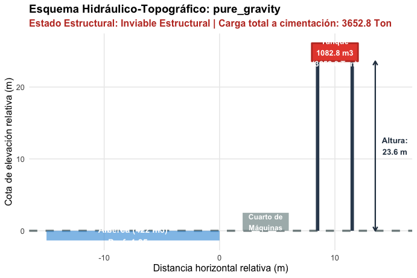

```r
plot_topography(sim_pura)
```

## 4. Simulación de la Solución Óptima: Bypass Gravitacional Híbrido

Para superar esta barrera, `gravitypool` implementa el algoritmo de **Bypass Híbrido**:

```r
sim_bypass <- simulate_gravity_system(escenario_cancun, mode = "hybrid_bypass")

# Estado estructural
cat("Estado de Factibilidad:", sim_bypass$feasibility, "\n")
```

```
#> Estado de Factibilidad: Viable
```

```r
cat("Carga total a cimentación:", sim_bypass$tank_sizing$total_gross_load_tons, "Toneladas\n")
```

```
#> Carga total a cimentación: 75.13 Toneladas
```

```r
cat("Inversión Inicial:", scales::dollar(sim_bypass$capex_usd$total), "\n")
```

```
#> Inversión Inicial: $23,940
```

Visualicemos la solución arquitectónica viable:

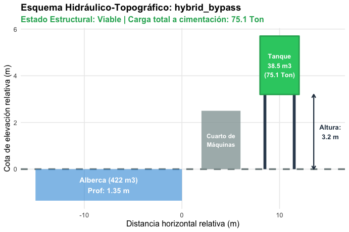

```r
plot_topography(sim_bypass)
```

## 5. Simulación de la Alternativa Tradicional: Baterías de Litio (LFP)

La alternativa convencional para independizarse de la red CFE en horario punta consiste en instalar un Sistema de Almacenamiento de Energía con Baterías (BESS).

Para alimentar las 3 motobombas (6.71 kW) durante las 14 horas nocturnas (93.9 kWh útiles) con un límite de descarga DoD del 85% y 90% de eficiencia, se requiere un banco de **122.8 kWh** de celdas LiFePO4:

```r
sim_bess <- simulate_battery_system(escenario_cancun)

cat("Capacidad Nominal Requerida:", sim_bess$battery_sizing$nameplate_capacity_kwh, "kWh\n")
```

```
#> Capacidad Nominal Requerida: 122.8 kWh
```

```r
cat("Módulos Rack (5 kWh c/u):", sim_bess$battery_sizing$battery_rack_modules_5kwh, "unidades\n")
```

```
#> Módulos Rack (5 kWh c/u): 24 unidades
```

```r
cat("Inversión Inicial Baterías:", scales::dollar(sim_bess$capex_usd$total), "\n")
```

```
#> Inversión Inicial Baterías: $85,382.50
```

## 6. Comparativa Estratégica Completa (`compare_scenarios`)

La función de alto nivel `compare_scenarios()` orquesta las simulaciones físicas, el análisis de Ciclo de Vida (LCA) a 20 años bajo normas ISO 14040/44 y la evaluación financiera de flujo de caja descontado a 15 años:

```r
comparativa <- compare_scenarios(escenario_cancun)
print(comparativa)
```

```
#> ========================================================================
#>   gravitypool :: COMPARATIVA ESTRATÉGICA DE ESCENARIOS
#> ========================================================================
#>   Proyecto: Alberca de Entrenamiento 25m - Cancún | Ubicación: Cancún, Quintana Roo
#> ------------------------------------------------------------------------
#>   1. COMPARATIVA DE INVERSIÓN INICIAL (CAPEX):
#>      - Red Convencional (BAU):        $       0 USD (OPEX actual: $11,950 USD/año)
#>      - Almacenamiento Baterías (LFP): $85,382 USD (Capacidad: 122.8 kWh)
#>      - Bypass Gravitacional Híbrido:  $23,940 USD (Tanque: 38.5 m3 @ 3.2 m)
#>      - Gravedad Pura (Fuerza Bruta):  $182,912 USD [ESTADO: Inviable Estructural]
#> ------------------------------------------------------------------------
#>   2. EVALUACIÓN FINANCIERA (15 Años):
#>      - Retorno de Inversión (Payback) Bypass:  2.1 años
#>      - Retorno de Inversión (Payback) Batería: NA años
#>      - Valor Actual Neto (NPV 8%) Bypass:     $75,269 USD
#>      - Valor Actual Neto (NPV 8%) Batería:    $-41,869 USD
#> ------------------------------------------------------------------------
#>   3. EVALUACIÓN DE CICLO DE VIDA (LCA 20 Años):
#>      - Emisiones Acumuladas Red CFE:           514,909 kg CO2e
#>      - Emisiones Acumuladas Baterías (LFP):    62,587 kg CO2e
#>      - Emisiones Acumuladas Bypass Híbrido:    9,546 kg CO2e
#>      - CO2e Ahorrado Bypass vs. Baterías:      53,041 kg CO2e (53.0 Ton)
#> ========================================================================
```

## 7. Análisis de Ciclo de Vida (LCA a 20 Años)

El gráfico de emisiones acumuladas revela por qué el bypass gravitacional es ambientalmente superior: * Las baterías de litio sufren una sustitución completa obligatoria cada **6 años** debido a la degradación cíclica severa en clima cálido. Cada reemplazo induce un escalón de emisiones por extracción y refinado de minerales. * El tanque gravitacional y la estructura de concreto tienen una vida útil superior a 50 años, manteniendo su huella de carbono **plana** tras la construcción inicial.

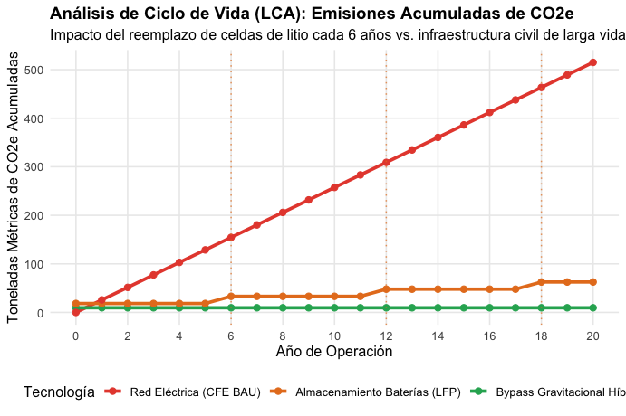

```r
plot_lca_emissions(comparativa)
```

## 8. Evaluación Financiera y Periodo de Retorno (Payback)

El flujo de caja acumulado compara el desembolso de capital y mantenimiento contra el gasto operativo baseline de la tarifa CFE GDMTH:

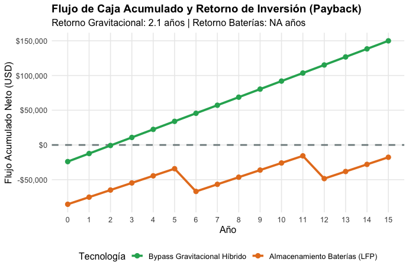

```r
plot_financial_payback(comparativa)
```

Desglose de la inversión inicial de capital (CAPEX):

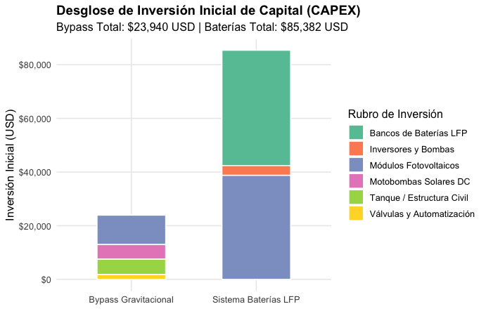

```r
plot_capex_breakdown(comparativa)
```